# Multiple linear regression

*A: Looking at scatterplot, residuals are randomly scattered around zero on the horizontal axis. This indicates Linearity condition is met.*

*Histogram suggests data are left skewed. This indicates there are some outliers. Normal probability plot shows that most data points are close to the line. Both graphs show enough evidence that data meets Nearly Normal condition.*

*Looking at scatterplot, the points have constant variance, with the residuals scattered randomly around zero on the horizontal axis. Since residuals do not show increasing or decreasing pattern, we can assume Constant Variance exists.*

*Using residual plots we can conclude conditions for least squares regression are reasonable.*

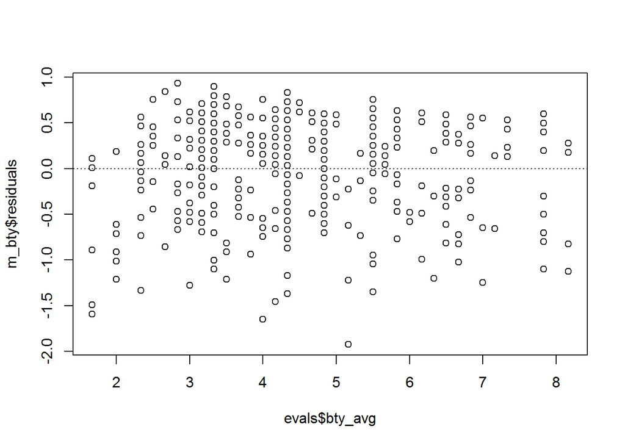

```r
#Scatter residual plot
m_bty <- lm(evals$score ~ evals$bty_avg)
plot(m_bty$residuals ~ evals$bty_avg)
abline(h = 0, lty = 3)
```

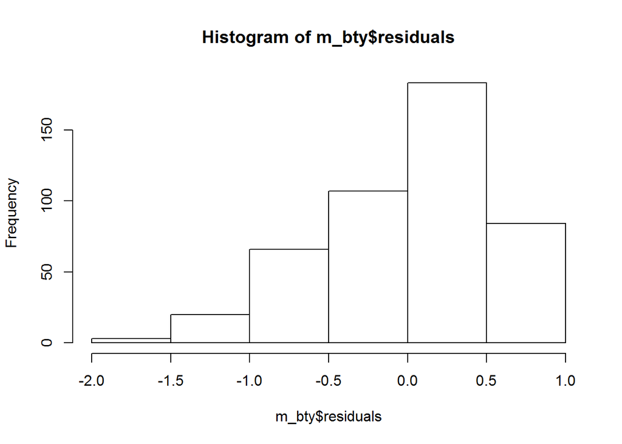

```r
#Residuals Histogram
hist(m_bty$residuals)
```

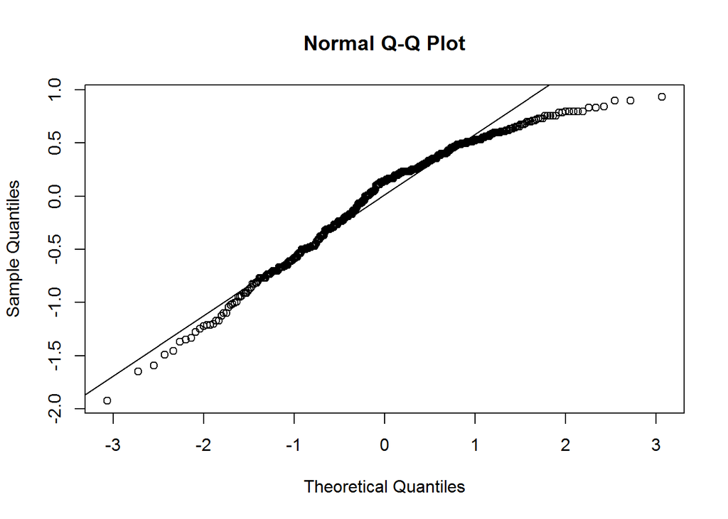

```r
# Nearly normal residuals using Normal probability plot
qqnorm(m_bty$residuals)
qqline(m_bty$residuals)  # adds diagonal line to the normal prob plot
```